# CS109A Introduction to Data Science

#### Histograms for our selected variables

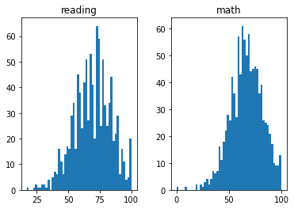

```python
df[['reading', 'math']].hist(bins=50, grid=False);
```

#### Histograms for our selected variables (seaborn)

[seaborn.histplot()](https://seaborn.pydata.org/generated/seaborn.histplot.html)

We can plot histogram in different plots using matplotlib subplots

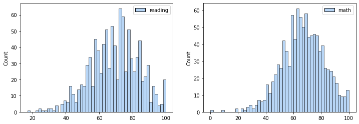

```python
plt.figure(figsize=(12,4))
sns.histplot(df[['reading']], bins=50, ax=plt.subplot(121), palette=palette)
sns.histplot(df[['math']], bins=50, ax=plt.subplot(122), palette=palette);
```

But knowing that by default sns.histplot merges all features into the same plot, it could be simpler

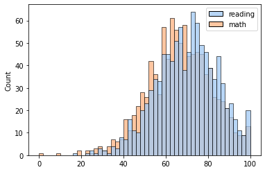

```python
sns.histplot(df[['reading', 'math']], bins=50, palette=palette);
```

#### Kernel Density Estimate

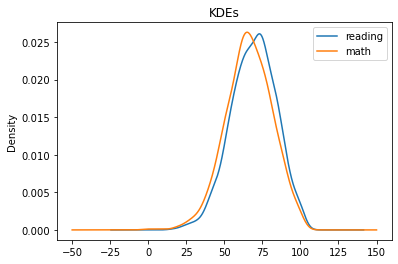

```python
df[['reading', 'math']].plot.kde()
plt.title('KDEs');
```

Seaborn comes with the method [`seaborn.kdeplot()`](https://seaborn.pydata.org/generated/seaborn.kdeplot.html) to create Kernel Density Plots but we can just set the histplot params kde to True to combine them.

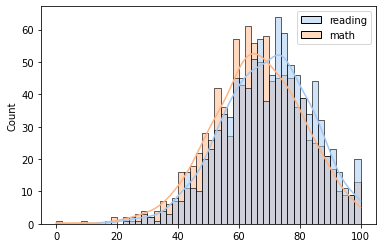

```python
sns.histplot(df[['reading', 'math']], bins=50, kde=True, palette=palette);
```

#### BoxPlot

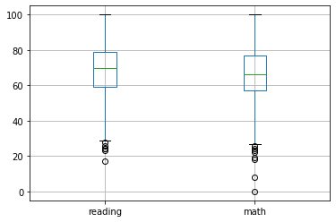

```python
df[['reading', 'math']].boxplot();
```

At first glance distributions looks similar as one could expect. Math scores distribution looks a bit shifted down.

**Boxplots with seaborn**

[`seanborn.boxplot()`](https://seaborn.pydata.org/generated/seaborn.boxplot.html)

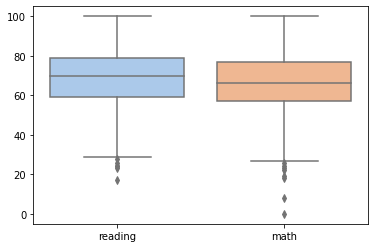

```python
sns.boxplot(data=df[['reading', 'math']], palette=palette);
```

**Boxenplots or Letter values**

[`seaborn.boxenplot()`](https://seaborn.pydata.org/generated/seaborn.boxenplot.html)

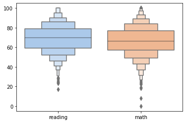

```python
sns.boxenplot(data=df[['reading', 'math']], palette=palette);
```

**Violinplots**

[`seaborn.violinplot()`](https://seaborn.pydata.org/generated/seaborn.violinplot.html)

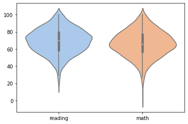

```python
sns.violinplot(data=df[['reading', 'math']], palette=palette);
```

What about the relation between the scores? Do they interact?

#### Scatter to the rescue

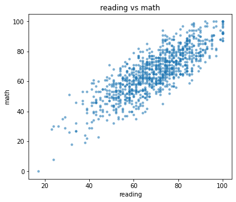

```python
df.plot.scatter(x='reading', y='math', s=10, alpha=.5, figsize=(6,5))
plt.title('reading vs math');
```

There is visual correlation between these variables.

### Correlation

Pandas has implemented a method named `corr()`.

`DataFrame.corr()`: Compute pairwise correlation of columns, excluding NA/null values.

```
DataFrame.corr(method='pearson', min_periods=1)
```

```python
df[['reading', 'math']].corr()
```

|  | reading | math |
| --- | --- | --- |
| reading | 1.00000 | 0.81758 |
| math | 0.81758 | 1.00000 |

Pandas corr() offers different correlation methods. In most cases `pearson` or/and `spearman` are the methods to go.

```python
for method in ['pearson', 'kendall', 'spearman']:
    # iloc is used to access value at first row second column.
    corr = df[['reading', 'math']].corr(method=method).iloc[0,1]
    print(f'{method} correlation: {corr:.3f}')
```

```
pearson correlation: 0.818
kendall correlation: 0.617
spearman correlation: 0.804
```

We've confirmed there is a strong (linear) correlation between reading and math scores. Each variable could work as a proxy of the other variable.

#### Boxplot on the whole dataframe

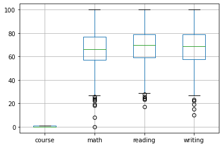

```python
df.boxplot();
```

#### Correlation between all variables

```python
df.corr()
```

|  | course | math | reading | writing |
| --- | --- | --- | --- | --- |
| course | 1.000000 | 0.177702 | 0.241780 | 0.312946 |
| math | 0.177702 | 1.000000 | 0.817580 | 0.802642 |
| reading | 0.241780 | 0.817580 | 1.000000 | 0.954598 |
| writing | 0.312946 | 0.802642 | 0.954598 | 1.000000 |

Reading and writing have a really strong correlation.

**Of course one could use plots**

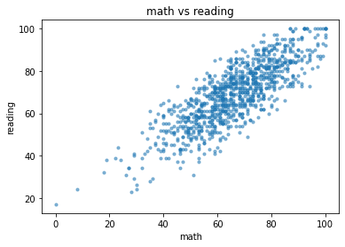

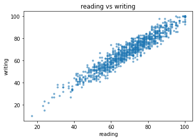

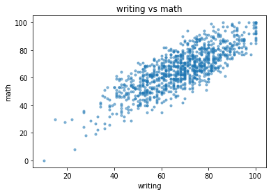

```python
cols = ['math', 'reading', 'writing']
for i, c1 in enumerate(cols):
    c2 = cols[i+1] if i < len(cols)-1 else cols[0]
    df.plot.scatter(x=c1, y=c2, s=10, alpha=.5)
    plt.title(f'{c1} vs {c2}')
```

**Scatter plots with seaborn**

Seaborn comes with [`seaborn.scatterplot()`](https://seaborn.pydata.org/generated/seaborn.scatterplot.html).

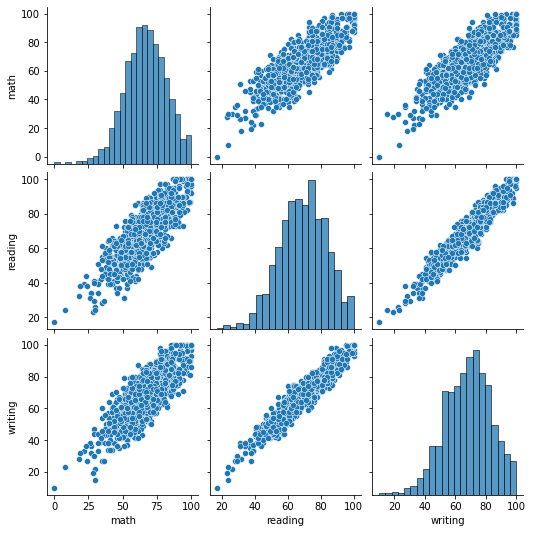

```python
sns.pairplot(df.select_dtypes('number'), palette=palette);
```

```python
df[['gender','math', 'reading', 'writing']].sample(5)
```

|  | gender | math | reading | writing |
| --- | --- | --- | --- | --- |
| 663 | female | 65 | 69 | 67 |
| 903 | female | 93 | 100 | 100 |
| 443 | female | 73 | 83 | 76 |
| 362 | female | 52 | 58 | 58 |
| 137 | male | 70 | 55 | 56 |

```python
df[['gender','math', 'reading', 'writing']].describe()
```

|  | math | reading | writing |
| --- | --- | --- | --- |
| count | 1000.00000 | 1000.000000 | 1000.000000 |
| mean | 66.08900 | 69.169000 | 68.054000 |
| std | 15.16308 | 14.600192 | 15.195657 |
| min | 0.00000 | 17.000000 | 10.000000 |
| 25% | 57.00000 | 59.000000 | 57.750000 |
| 50% | 66.00000 | 70.000000 | 69.000000 |
| 75% | 77.00000 | 79.000000 | 79.000000 |
| max | 100.00000 | 100.000000 | 100.000000 |

#### Pie plot

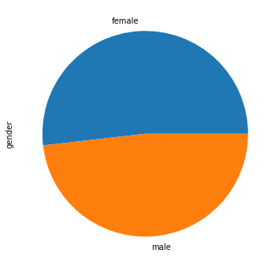

```python
df['gender'].value_counts(normalize=True).plot.pie(figsize=(6,6));
```

Seaborn doesn't come with a method to plot pie plots

```python
df.groupby('gender').mean()
```

| gender | course | math | reading | writing |
| --- | --- | --- | --- | --- |
| female | 0.355212 | 63.633205 | 72.608108 | 72.467181 |
| male | 0.360996 | 68.728216 | 65.473029 | 63.311203 |

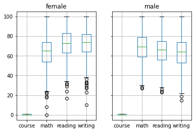

```python
df.groupby('gender').boxplot();
```

pandas.melt() is a powerful method to unpivot a dataframe. We are going to use it to simplify use of some seaborn plots.

```python
score_cols = df.select_dtypes('number').columns.tolist()
id_vars = [c for c in df.columns if c not in score_cols]
score_cols, id_vars
melted = pd.melt(df, id_vars=id_vars, var_name='skill', value_name='score')
melted.head()
```

|  | gender | group | parental | lunch | course | skill | score |
| --- | --- | --- | --- | --- | --- | --- | --- |
| 0 | female | B | bachelor's degree | standard | False | math | 72 |
| 1 | female | C | some college | standard | True | math | 69 |
| 2 | female | B | master's degree | standard | False | math | 90 |
| 3 | male | A | associate's degree | free/reduced | False | math | 47 |
| 4 | male | C | some college | standard | False | math | 76 |

When you make things easier to read for seaborn, seaborn will make the plots easier to read for you.

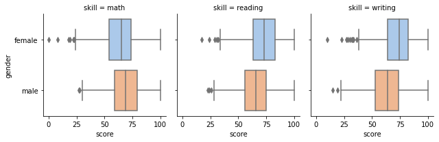

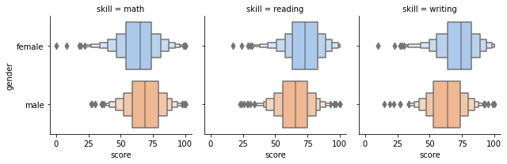

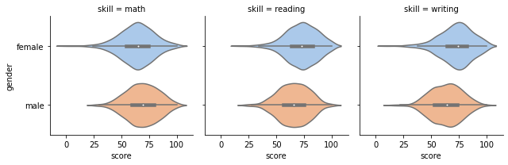

```python
for func in [sns.boxplot, sns.boxenplot, sns.violinplot]:
    g = sns.FacetGrid(melted, col="skill")
    g.map(func, 'score', 'gender', order=None, palette=palette);
```

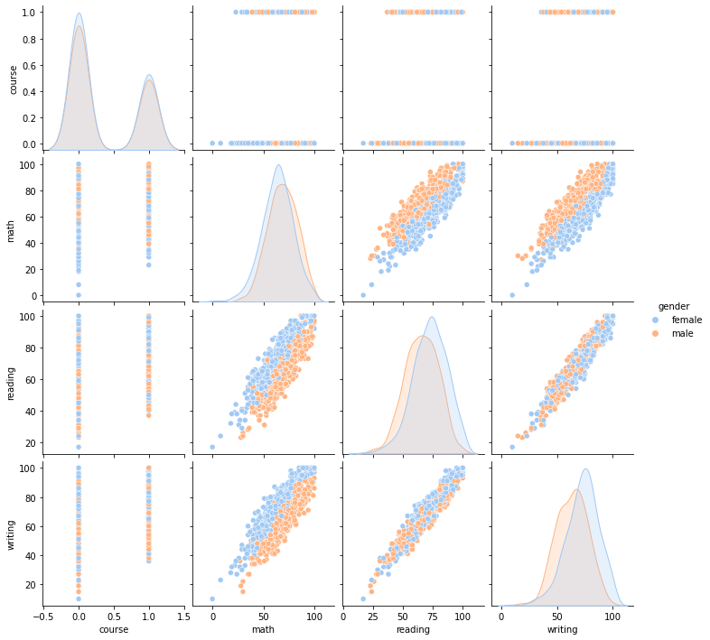

```python
sns.pairplot(df, palette=palette, hue='gender');
```

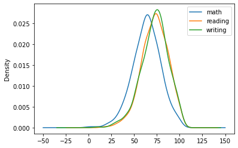

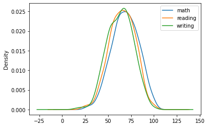

```python
df.groupby('gender').plot.kde();
```

```python
df['is_female'] = df['gender'].apply(lambda x: 1 if x == 'female' else 0)
df['is_female'] = df['is_female'].astype(float)

df['is_male'] = df['gender'].apply(lambda x: 1 if x == 'male' else 0)
df['is_male'] = df['is_male'].astype(float)

df.head()
```

|  | gender | group | parental | lunch | course | math | reading | writing | is_female | is_male |
| --- | --- | --- | --- | --- | --- | --- | --- | --- | --- | --- |
| 0 | female | B | bachelor's degree | standard | False | 72 | 72 | 74 | 1.0 | 0.0 |
| 1 | female | C | some college | standard | True | 69 | 90 | 88 | 1.0 | 0.0 |
| 2 | female | B | master's degree | standard | False | 90 | 95 | 93 | 1.0 | 0.0 |
| 3 | male | A | associate's degree | free/reduced | False | 47 | 57 | 44 | 0.0 | 1.0 |
| 4 | male | C | some college | standard | False | 76 | 78 | 75 | 0.0 | 1.0 |

Instead of looking at correlation between all variables we want to see how this new variables `is_female` correlates with the scores. Pandas gives us the method `DataFrame.corrwith()` for this kind of cases.

```python
df[['math', 'reading', 'writing']].corrwith(df['is_female'])
```

```
math      -0.167982
reading    0.244313
writing    0.301225
dtype: float64
```

```python
df[['math', 'reading', 'writing']].corrwith(df['is_male'])
```

```
math       0.167982
reading   -0.244313
writing   -0.301225
dtype: float64
```

#### One Hot Encoding

What we have just done is known as One Hot Encoding of the `gender` variable.

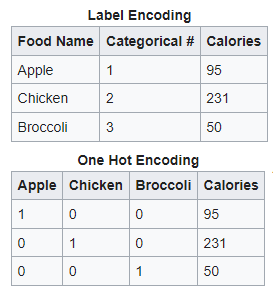

Pandas has a method to simplify this kind of conversion under the name: `get_dummies()`

`pd.get_dummies()`: Convert categorical variable into dummy/indicator variables.

```
pandas.get_dummies(data, prefix=None, prefix_sep='_', dummy_na=False, columns=None,
                   sparse=False, drop_first=False, dtype=None)
```

```python
pd.get_dummies(df['gender']).head()
```

|  | female | male |
| --- | --- | --- |
| 0 | 1 | 0 |
| 1 | 1 | 0 |
| 2 | 1 | 0 |
| 3 | 0 | 1 |
| 4 | 0 | 1 |

In example, we could make use of this method to create a new DataFrame with the scores and the one hot encoded version of gender variable. We use `get_dummies()` to encode the categorical gender variable and then we use the `pd.concat()` method to concatenate two DataFrames on the horizonal axis.

```python
df_encoded = pd.concat([df[['math', 'reading', 'writing']], pd.get_dummies(df['gender'])], axis=1)
df_encoded.head()
```

|  | math | reading | writing | female | male |
| --- | --- | --- | --- | --- | --- |
| 0 | 72 | 72 | 74 | 1 | 0 |
| 1 | 69 | 90 | 88 | 1 | 0 |
| 2 | 90 | 95 | 93 | 1 | 0 |
| 3 | 47 | 57 | 44 | 0 | 1 |
| 4 | 76 | 78 | 75 | 0 | 1 |

And then using one line of code more we could arrive to the same conclusions

```python
df_encoded.corr()
```

|  | math | reading | writing | female | male |
| --- | --- | --- | --- | --- | --- |
| math | 1.000000 | 0.817580 | 0.802642 | -0.167982 | 0.167982 |
| reading | 0.817580 | 1.000000 | 0.954598 | 0.244313 | -0.244313 |
| writing | 0.802642 | 0.954598 | 1.000000 | 0.301225 | -0.301225 |
| female | -0.167982 | 0.244313 | 0.301225 | 1.000000 | -1.000000 |
| male | 0.167982 | -0.244313 | -0.301225 | -1.000000 | 1.000000 |

**Extra**

Most of ML models don't work with categorial variables. You will become familiar with method like get_dummies() from pandas or similar ones from other libraries to prepare the data that will feed your models. Sometimes, it is convenient to normalize or standardize the data. We already known that the new dataset ranges, so we could normalize it using one line of code.

```python
df_normalized = df_encoded.div(df_encoded.max() - df_encoded.min())
df_normalized.head()
```

|  | math | reading | writing | female | male |
| --- | --- | --- | --- | --- | --- |
| 0 | 0.72 | 0.867470 | 0.822222 | 1.0 | 0.0 |
| 1 | 0.69 | 1.084337 | 0.977778 | 1.0 | 0.0 |
| 2 | 0.90 | 1.144578 | 1.033333 | 1.0 | 0.0 |
| 3 | 0.47 | 0.686747 | 0.488889 | 0.0 | 1.0 |
| 4 | 0.76 | 0.939759 | 0.833333 | 0.0 | 1.0 |

The new dataset `df_normalized` looks like a generic dataset for any kind of ML algorithm

And we can check that we don't change correlations after normalizing them.

```python
df_normalized.corr().round(14) == df_encoded.corr().round(14)
```

|  | math | reading | writing | female | male |
| --- | --- | --- | --- | --- | --- |
| math | True | True | True | True | True |
| reading | True | True | True | True | True |
| writing | True | True | True | True | True |
| female | True | True | True | True | True |
| male | True | True | True | True | True |

### Heatmap

[`seaborn.heatmap()`](https://seaborn.pydata.org/generated/seaborn.heatmap.html): Plot rectangular data as a color-encoded matrix.

Heatmap is a great tool for plotting features' correlations

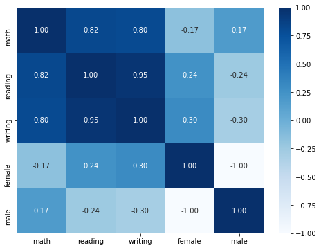

```python
fig, ax = plt.subplots(1, 1, figsize=(8,6))
sns.heatmap(df_normalized.corr(), annot=True, fmt='.2f', cmap='Blues', ax=ax);
```

### Who will approve?

```python
approval_threshold = 40
```

```python
df['approved'] = df['math'] >= approval_threshold
df['approved'] = df['approved'].astype(int)
df.head()
```

|  | gender | group | parental | lunch | course | math | reading | writing | is_female | is_male | approved |
| --- | --- | --- | --- | --- | --- | --- | --- | --- | --- | --- | --- |
| 0 | female | B | bachelor's degree | standard | False | 72 | 72 | 74 | 1.0 | 0.0 | 1 |
| 1 | female | C | some college | standard | True | 69 | 90 | 88 | 1.0 | 0.0 | 1 |
| 2 | female | B | master's degree | standard | False | 90 | 95 | 93 | 1.0 | 0.0 | 1 |
| 3 | male | A | associate's degree | free/reduced | False | 47 | 57 | 44 | 0.0 | 1.0 | 1 |
| 4 | male | C | some college | standard | False | 76 | 78 | 75 | 0.0 | 1.0 | 1 |

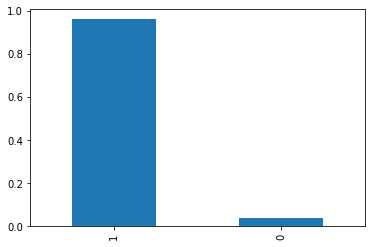

```python
df['approved'].value_counts(normalize=True).plot.bar();
```

Seaborn has a method for plotting counts of feature's values.

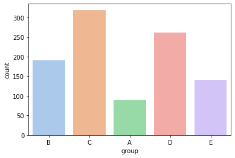

```python
sns.countplot(data=df, x='group', palette=palette);
```

The problem is that the countplot method doesn't *count* with a normalize parameter. So trying to plot a normalized version is to so simple as when using pandas (`Series.value_counts(normalize=True).plot.bar()`)

```python
df['approved'].value_counts(normalize=True).to_frame()
```

|  | approved |
| --- | --- |
| 1 | 0.96 |
| 0 | 0.04 |

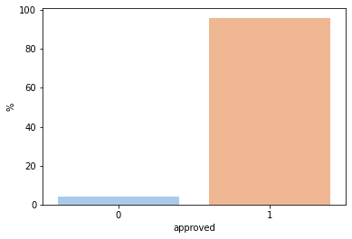

```python
sns.barplot(data=((df['approved'].value_counts(normalize=True)*100).to_frame()
                     .reset_index().rename(columns={'approved': '%', 'index': 'approved'})),
            x='approved',
            y='%',
            palette=palette);
```

```python
df[['gender', 'course', 'reading', 'writing', 'math']].groupby('gender').corrwith(df['approved'])
```

| gender | course | reading | writing | math |
| --- | --- | --- | --- | --- |
| female | 0.102233 | 0.513812 | 0.549594 | 0.548292 |
| male | 0.071767 | 0.317447 | 0.331337 | 0.339371 |

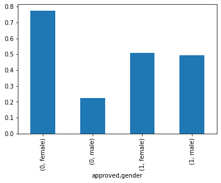

```python
df.groupby('approved')['gender'].value_counts(normalize=True).plot.bar();
```

We will try to do the same plot with seaborn

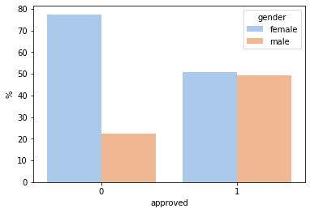

```python
tmp = (df.groupby('approved')['gender'].value_counts(normalize=True).to_frame().rename(columns={'gender': '%'})*100).reset_index()
sns.barplot(data=tmp, x='approved', y='%', hue='gender', palette=palette);
```

## Years in a cell

When plotting you can think of using one of these four approaches:

- Pandas
- Pandas + Matplotlib
- Pandas + Seaborn
- Pandas + Seaborn + Matplotlib

**Pandas**

- Learning: easy
- Default Visual: bad
- Custom Visual: regular
- TIP: just knowing what are the plotting methods implemented in pandas is enough to start plotting many things to extract information for you (but maybe not for a presentation).

**Pandas + Matplotlib**

- Learning: difficult
- Default Visual: regular
- Custom Visual: excellent but tricky (it's all about learning matplotlib, not easy to start from scratch)
- TIP: Think the plot you want and then using DataFrame.groupby or some condition applied to the dataframe will be enough to feed your plots.

**Pandas + Seaborn**

- Learning: good
- Default Visual: good
- Custom Visual: very good
- TIP: Seaborn is almost about preparing a DataFrame to feed the seaborn plot you are looking for. So you need to learn about Seaborn's available plots and probably expend some time learning pandas methods like `melt` and `pivot` to transform the dataframe in an input kind of the ones seaborn likes.

**Pandas + Matplotlib + Seaborn**

- Learning: difficult
- Default Visual: good
- Custom Visual: excellent
- TIP: Sky is the limit. Remember that seaborn was built on matplotlib.

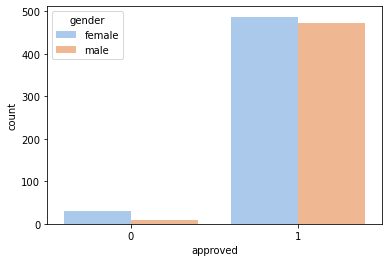

```python
sns.countplot(data=df, x='approved', hue='gender', palette=palette);
```

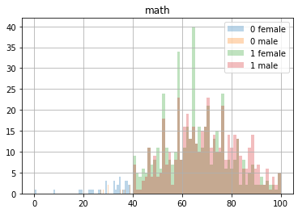

```python
ax = plt.subplot()
for group, g in df.groupby(['approved','gender']):
    g[['math']].hist(bins=50, ax=ax, alpha=.3, label=f'{group[0]} {group[1]}');
plt.legend();
```

To do the same plot with seaborn we will need to convert the dataframe like the melted one and add some new column that represents a combination of gender and approved. Sometimes it's better to look for alternatives that let us do the same analysis without too much coding.

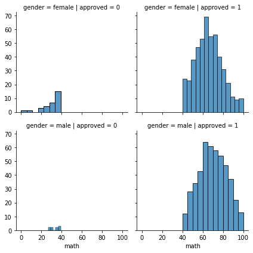

```python
g = sns.FacetGrid(df, col='approved', row='gender')
g.map(sns.histplot, 'math', palette=palette);
```

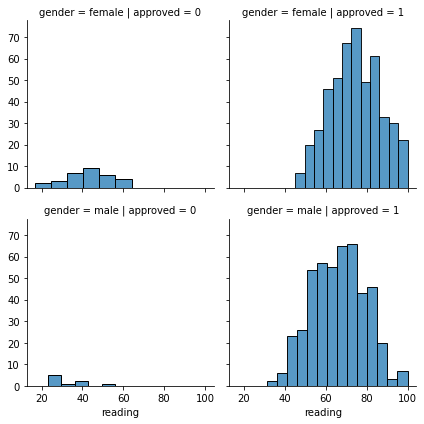

```python
g = sns.FacetGrid(df, col='approved', row='gender')
g.map(sns.histplot, 'reading', palette=palette);
```

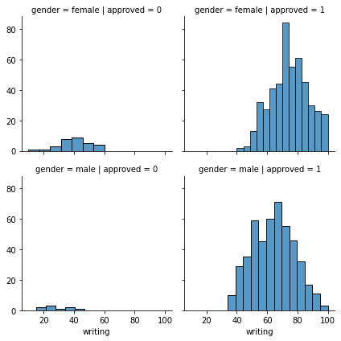

```python
g = sns.FacetGrid(df, col='approved', row='gender')
g.map(sns.histplot, 'writing', palette=palette);
```

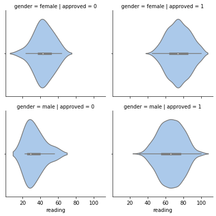

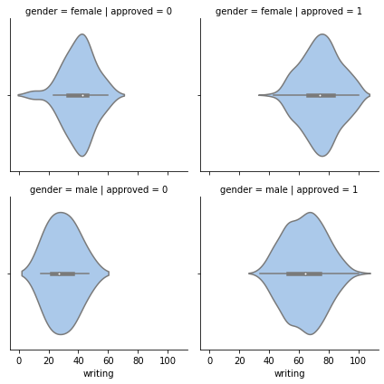

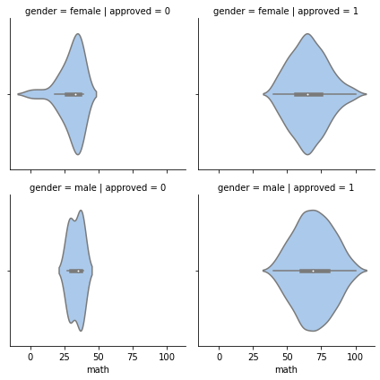

```python
# let's repeat the three features with violinplots
for feature in ['reading', 'writing', 'math']:
    g = sns.FacetGrid(df, col='approved', row='gender', sharex=True, sharey=True)
    g.map(sns.violinplot, feature, order=None, palette=palette);
```

If we prepare data for seaborn, seaborn will give what we want. For instance, `seaborn.violinplot()` permits to split the violin distribution using a secondary binary `hue` feature. But this just can be done when using parameters `x` and `y`. In this case we can use a dummy feature to plot what we want. Knowing this will help us to improve our previous plot.

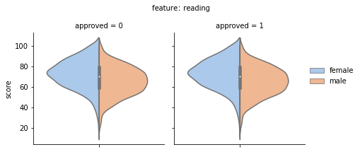

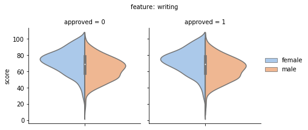

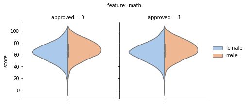

```python
df['dummy'] = ''
# let's repeat the three features with violinplots
for feature in ['reading', 'writing', 'math']:
    g = sns.FacetGrid(df, col='approved', sharey=True)
    g.map(sns.violinplot, data=df, x='dummy', y=feature, hue='gender', split=True, order=None, palette=palette);
    g.add_legend() # we want to display the gender legend
    g.set_ylabels('score')
    g.fig.subplots_adjust(top=0.8)
    g.fig.suptitle(f'feature: {feature}', fontsize=12, font='verdana')
del df['dummy']
```

### PairGrid

seaborn.PairGrid() is a great tool that let us extend seaborn plots easily.

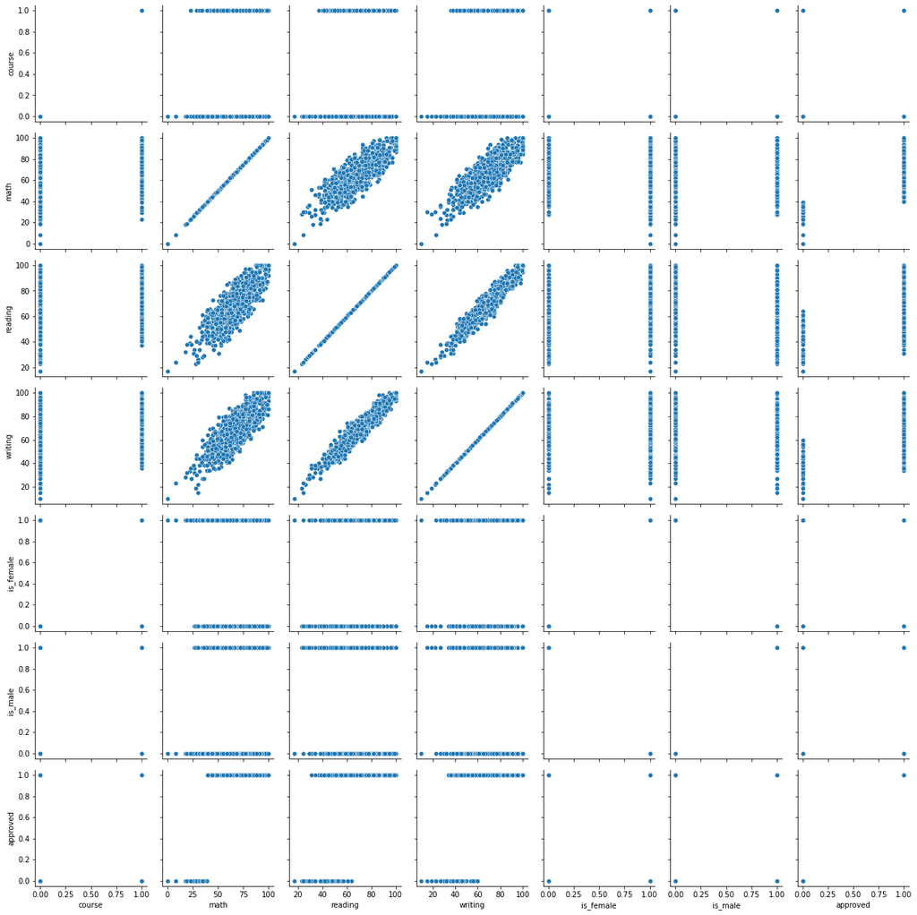

```python
# this should do something similar to pairplot() but without setting the histogram in the diagonal
g = sns.PairGrid(df)
g.map(sns.scatterplot);
```

```python
del df['is_female']
del df['is_male']
```

Maybe you didn't see the power of PairGrids. Let's try again with a new custom PairGrid plot with multivariate KDE subplots

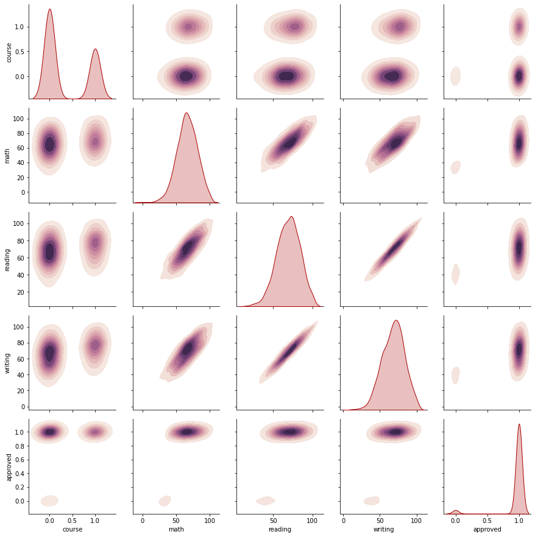

```python
# Create a cubehelix colormap to use with kdeplot
cmap = sns.cubehelix_palette(start=0, light=.95, as_cmap=True)
g = sns.PairGrid(df, diag_sharey=False)
g.map_upper(sns.kdeplot, cmap=cmap, fill=True)
g.map_lower(sns.kdeplot, cmap=cmap, fill=True)
g.map_diag(sns.kdeplot, color='#aa0000', fill=True);
```

# Summary

**In this lecture you've learnt:**

### Some important things about using SEABORN with PANDAS!

- Importance of plots
- Using pandas for EDA
- Notion of One Hot Encoding

**Pandas**

- pandas.read_csv()
- pandas.concat()
- pandas.get_dummies()
- DataFrame.info()
- DataFrame.head()
- DataFrame.sample()
- DataFrame.describe()
- DataFrame.unique()
- DataFrame.str
- DataFrame.grouby()
- DataFrame.sourt_values()
- DataFrame.corr()
- DataFrame.corrwith()
- DataFrameGroupBy.size()

**Pandas (plotting)**

- DataFrame.boxplot()
- DataFrame.hist()
- DataFrame.plot()
- DataFrame.plot.kde()
- DataFrame.plot.pie()
- DataFrame.plot.scatter()

**matplotlib**

- matplotlib.pyplot.subplots()
- matplotlib.pyplot.title()
- matplotlib.pyplot.plot()
- matplotlib.pyplot.suptitle()
- matplotlib.pyplot.subplot()
- matplotlib.pyplot.subplots_adjust()
- matplotlib.pyplot.ylabel()
- matplotlib.pyplot.legend()
- matplotlib.pyplot.figure()

**seaborn**

- seaborn.boxplot()
- seaborn.boxenplot()
- seaborn.histplot()
- seaborn.barplot()
- seaborn.countplot()
- seaborn.scatterplot()
- seaborn.violinplot()
- seaborn.lineplot()
- seaborn.pairplot()
- seaborn.heatmap()
- seaborn.kdeplot()
- seaborn.FacetGrid()
- seaborn.PairGrid()